# Risk Factor Analysis

## Outcome Variable

**Outcome Variable:** wast_rec90d

## Predictor Variables

**Intervention Variable:** nchldlt5

**Adjustment Set:**

- arm
- W_mage
- meducyrs
- feducyrs
- hhwealth_quart
- hfoodsec
- W_mhtcm
- W_nrooms
- W_parity
- impfloor
- impsan
- safeh20
- delta_W_mage
- delta_meducyrs
- delta_feducyrs
- delta_hhwealth_quart
- delta_hfoodsec
- delta_W_mhtcm
- delta_W_nrooms
- delta_W_parity
- delta_impfloor
- delta_impsan
- delta_safeh20

## Stratifying Variables

The analysis was stratified on these variable(s):

- agecat
- studyid
- country

## Data Summary

| agecat | studyid | country | nchldlt5 | wast_rec90d | n_cell | n |
| --- | --- | --- | --- | --- | --- | --- |
| 0-24 months | ki1000108-IRC | INDIA | 1 | 0 | 39 | 395 |
| 0-24 months | ki1000108-IRC | INDIA | 1 | 1 | 56 | 395 |
| 0-24 months | ki1000108-IRC | INDIA | 2+ | 0 | 123 | 395 |
| 0-24 months | ki1000108-IRC | INDIA | 2+ | 1 | 177 | 395 |
| 0-24 months | ki1017093b-PROVIDE | BANGLADESH | 1 | 0 | 87 | 307 |
| 0-24 months | ki1017093b-PROVIDE | BANGLADESH | 1 | 1 | 137 | 307 |
| 0-24 months | ki1017093b-PROVIDE | BANGLADESH | 2+ | 0 | 41 | 307 |
| 0-24 months | ki1017093b-PROVIDE | BANGLADESH | 2+ | 1 | 42 | 307 |
| 0-24 months | ki1017093c-NIH-Crypto | BANGLADESH | 1 | 0 | 73 | 311 |
| 0-24 months | ki1017093c-NIH-Crypto | BANGLADESH | 1 | 1 | 137 | 311 |
| 0-24 months | ki1017093c-NIH-Crypto | BANGLADESH | 2+ | 0 | 44 | 311 |
| 0-24 months | ki1017093c-NIH-Crypto | BANGLADESH | 2+ | 1 | 57 | 311 |
| 0-24 months | ki1066203-TanzaniaChild2 | TANZANIA, UNITED REPUBLIC OF | 1 | 0 | 186 | 711 |
| 0-24 months | ki1066203-TanzaniaChild2 | TANZANIA, UNITED REPUBLIC OF | 1 | 1 | 315 | 711 |
| 0-24 months | ki1066203-TanzaniaChild2 | TANZANIA, UNITED REPUBLIC OF | 2+ | 0 | 80 | 711 |
| 0-24 months | ki1066203-TanzaniaChild2 | TANZANIA, UNITED REPUBLIC OF | 2+ | 1 | 130 | 711 |
| 0-24 months | ki1112895-iLiNS-Zinc | BURKINA FASO | 1 | 0 | 241 | 787 |
| 0-24 months | ki1112895-iLiNS-Zinc | BURKINA FASO | 1 | 1 | 10 | 787 |
| 0-24 months | ki1112895-iLiNS-Zinc | BURKINA FASO | 2+ | 0 | 512 | 787 |
| 0-24 months | ki1112895-iLiNS-Zinc | BURKINA FASO | 2+ | 1 | 24 | 787 |
| 0-24 months | ki1148112-LCNI-5 | MALAWI | 1 | 0 | 25 | 78 |
| 0-24 months | ki1148112-LCNI-5 | MALAWI | 1 | 1 | 6 | 78 |
| 0-24 months | ki1148112-LCNI-5 | MALAWI | 2+ | 0 | 40 | 78 |
| 0-24 months | ki1148112-LCNI-5 | MALAWI | 2+ | 1 | 7 | 78 |
| 0-24 months | kiGH5241-JiVitA-3 | BANGLADESH | 1 | 0 | 2740 | 7566 |
| 0-24 months | kiGH5241-JiVitA-3 | BANGLADESH | 1 | 1 | 2149 | 7566 |
| 0-24 months | kiGH5241-JiVitA-3 | BANGLADESH | 2+ | 0 | 1629 | 7566 |
| 0-24 months | kiGH5241-JiVitA-3 | BANGLADESH | 2+ | 1 | 1048 | 7566 |
| 0-6 months | ki1000108-IRC | INDIA | 1 | 0 | 20 | 240 |
| 0-6 months | ki1000108-IRC | INDIA | 1 | 1 | 37 | 240 |
| 0-6 months | ki1000108-IRC | INDIA | 2+ | 0 | 67 | 240 |
| 0-6 months | ki1000108-IRC | INDIA | 2+ | 1 | 116 | 240 |
| 0-6 months | ki1017093b-PROVIDE | BANGLADESH | 1 | 0 | 25 | 184 |
| 0-6 months | ki1017093b-PROVIDE | BANGLADESH | 1 | 1 | 115 | 184 |
| 0-6 months | ki1017093b-PROVIDE | BANGLADESH | 2+ | 0 | 14 | 184 |
| 0-6 months | ki1017093b-PROVIDE | BANGLADESH | 2+ | 1 | 30 | 184 |
| 0-6 months | ki1017093c-NIH-Crypto | BANGLADESH | 1 | 0 | 14 | 198 |
| 0-6 months | ki1017093c-NIH-Crypto | BANGLADESH | 1 | 1 | 125 | 198 |
| 0-6 months | ki1017093c-NIH-Crypto | BANGLADESH | 2+ | 0 | 7 | 198 |
| 0-6 months | ki1017093c-NIH-Crypto | BANGLADESH | 2+ | 1 | 52 | 198 |
| 0-6 months | ki1066203-TanzaniaChild2 | TANZANIA, UNITED REPUBLIC OF | 1 | 0 | 66 | 339 |
| 0-6 months | ki1066203-TanzaniaChild2 | TANZANIA, UNITED REPUBLIC OF | 1 | 1 | 170 | 339 |
| 0-6 months | ki1066203-TanzaniaChild2 | TANZANIA, UNITED REPUBLIC OF | 2+ | 0 | 35 | 339 |
| 0-6 months | ki1066203-TanzaniaChild2 | TANZANIA, UNITED REPUBLIC OF | 2+ | 1 | 68 | 339 |
| 0-6 months | ki1148112-LCNI-5 | MALAWI | 1 | 0 | 1 | 4 |
| 0-6 months | ki1148112-LCNI-5 | MALAWI | 1 | 1 | 0 | 4 |
| 0-6 months | ki1148112-LCNI-5 | MALAWI | 2+ | 0 | 3 | 4 |
| 0-6 months | ki1148112-LCNI-5 | MALAWI | 2+ | 1 | 0 | 4 |
| 0-6 months | kiGH5241-JiVitA-3 | BANGLADESH | 1 | 0 | 953 | 4734 |
| 0-6 months | kiGH5241-JiVitA-3 | BANGLADESH | 1 | 1 | 2149 | 4734 |
| 0-6 months | kiGH5241-JiVitA-3 | BANGLADESH | 2+ | 0 | 584 | 4734 |
| 0-6 months | kiGH5241-JiVitA-3 | BANGLADESH | 2+ | 1 | 1048 | 4734 |
| 6-24 months | ki1000108-IRC | INDIA | 1 | 0 | 19 | 155 |
| 6-24 months | ki1000108-IRC | INDIA | 1 | 1 | 19 | 155 |
| 6-24 months | ki1000108-IRC | INDIA | 2+ | 0 | 56 | 155 |
| 6-24 months | ki1000108-IRC | INDIA | 2+ | 1 | 61 | 155 |
| 6-24 months | ki1017093b-PROVIDE | BANGLADESH | 1 | 0 | 62 | 123 |
| 6-24 months | ki1017093b-PROVIDE | BANGLADESH | 1 | 1 | 22 | 123 |
| 6-24 months | ki1017093b-PROVIDE | BANGLADESH | 2+ | 0 | 27 | 123 |
| 6-24 months | ki1017093b-PROVIDE | BANGLADESH | 2+ | 1 | 12 | 123 |
| 6-24 months | ki1017093c-NIH-Crypto | BANGLADESH | 1 | 0 | 59 | 113 |
| 6-24 months | ki1017093c-NIH-Crypto | BANGLADESH | 1 | 1 | 12 | 113 |
| 6-24 months | ki1017093c-NIH-Crypto | BANGLADESH | 2+ | 0 | 37 | 113 |
| 6-24 months | ki1017093c-NIH-Crypto | BANGLADESH | 2+ | 1 | 5 | 113 |
| 6-24 months | ki1066203-TanzaniaChild2 | TANZANIA, UNITED REPUBLIC OF | 1 | 0 | 120 | 372 |
| 6-24 months | ki1066203-TanzaniaChild2 | TANZANIA, UNITED REPUBLIC OF | 1 | 1 | 145 | 372 |
| 6-24 months | ki1066203-TanzaniaChild2 | TANZANIA, UNITED REPUBLIC OF | 2+ | 0 | 45 | 372 |
| 6-24 months | ki1066203-TanzaniaChild2 | TANZANIA, UNITED REPUBLIC OF | 2+ | 1 | 62 | 372 |
| 6-24 months | ki1112895-iLiNS-Zinc | BURKINA FASO | 1 | 0 | 241 | 787 |
| 6-24 months | ki1112895-iLiNS-Zinc | BURKINA FASO | 1 | 1 | 10 | 787 |
| 6-24 months | ki1112895-iLiNS-Zinc | BURKINA FASO | 2+ | 0 | 512 | 787 |
| 6-24 months | ki1112895-iLiNS-Zinc | BURKINA FASO | 2+ | 1 | 24 | 787 |
| 6-24 months | ki1148112-LCNI-5 | MALAWI | 1 | 0 | 24 | 74 |
| 6-24 months | ki1148112-LCNI-5 | MALAWI | 1 | 1 | 6 | 74 |
| 6-24 months | ki1148112-LCNI-5 | MALAWI | 2+ | 0 | 37 | 74 |
| 6-24 months | ki1148112-LCNI-5 | MALAWI | 2+ | 1 | 7 | 74 |
| 6-24 months | kiGH5241-JiVitA-3 | BANGLADESH | 1 | 0 | 1787 | 2832 |
| 6-24 months | kiGH5241-JiVitA-3 | BANGLADESH | 1 | 1 | 0 | 2832 |
| 6-24 months | kiGH5241-JiVitA-3 | BANGLADESH | 2+ | 0 | 1045 | 2832 |
| 6-24 months | kiGH5241-JiVitA-3 | BANGLADESH | 2+ | 1 | 0 | 2832 |

The following strata were considered:

- agecat: 0-24 months, studyid: ki1000108-IRC, country: INDIA
- agecat: 0-24 months, studyid: ki1017093b-PROVIDE, country: BANGLADESH
- agecat: 0-24 months, studyid: ki1017093c-NIH-Crypto, country: BANGLADESH
- agecat: 0-24 months, studyid: ki1066203-TanzaniaChild2, country: TANZANIA, UNITED REPUBLIC OF
- agecat: 0-24 months, studyid: ki1112895-iLiNS-Zinc, country: BURKINA FASO
- agecat: 0-24 months, studyid: ki1148112-LCNI-5, country: MALAWI
- agecat: 0-24 months, studyid: kiGH5241-JiVitA-3, country: BANGLADESH
- agecat: 0-6 months, studyid: ki1000108-IRC, country: INDIA
- agecat: 0-6 months, studyid: ki1017093b-PROVIDE, country: BANGLADESH
- agecat: 0-6 months, studyid: ki1017093c-NIH-Crypto, country: BANGLADESH
- agecat: 0-6 months, studyid: ki1066203-TanzaniaChild2, country: TANZANIA, UNITED REPUBLIC OF
- agecat: 0-6 months, studyid: ki1148112-LCNI-5, country: MALAWI
- agecat: 0-6 months, studyid: kiGH5241-JiVitA-3, country: BANGLADESH
- agecat: 6-24 months, studyid: ki1000108-IRC, country: INDIA
- agecat: 6-24 months, studyid: ki1017093b-PROVIDE, country: BANGLADESH
- agecat: 6-24 months, studyid: ki1017093c-NIH-Crypto, country: BANGLADESH
- agecat: 6-24 months, studyid: ki1066203-TanzaniaChild2, country: TANZANIA, UNITED REPUBLIC OF
- agecat: 6-24 months, studyid: ki1112895-iLiNS-Zinc, country: BURKINA FASO
- agecat: 6-24 months, studyid: ki1148112-LCNI-5, country: MALAWI
- agecat: 6-24 months, studyid: kiGH5241-JiVitA-3, country: BANGLADESH

### Dropped Strata

Some strata were dropped due to rare outcomes:

- agecat: 0-6 months, studyid: ki1148112-LCNI-5, country: MALAWI
- agecat: 6-24 months, studyid: kiGH5241-JiVitA-3, country: BANGLADESH

## Methods Detail

We’re interested in the causal parameters $E[Y_a]$ for all values of $a \in \mathcal{A}$. These parameters represent the mean outcome if, possibly contrary to fact, we intervened to set all units to have $A=a$. Under the randomization and positivity assumptions, these are identified by the statistical parameters $\psi_a=E_W[E_{Y|A,W}(Y|A=a,W)]$. In addition, we’re interested in the mean of $Y$, $E[Y]$ under no intervention (the observed mean). We will estimate these parameters by using SuperLearner to fit the relevant likelihood factors – $E_{Y|A,W}(Y|A=a,W)$ and $p(A=a|W)$, and then updating our likelihood fit using a joint TMLE.

For unadjusted analyses ($W=\{\}$), initial likelihoods were estimated using Lrnr_glm to estimate the simple $E(Y|A)$ and Lrnr_mean to estimate $p(A)$. For adjusted analyses, a small library containing Lrnr_glmnet, Lrnr_xgboost, and Lrnr_mean was used.

Having estimated these parameters, we will then use the delta method to estimate relative risks and attributable risks relative to a prespecified baseline level of $A$.

# Results Detail

## Results Plots

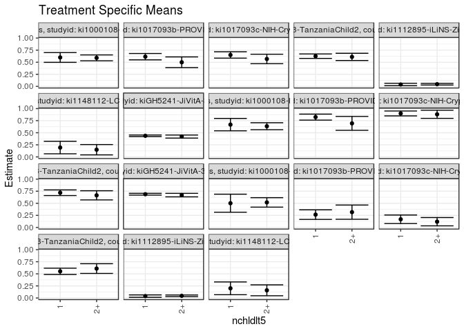

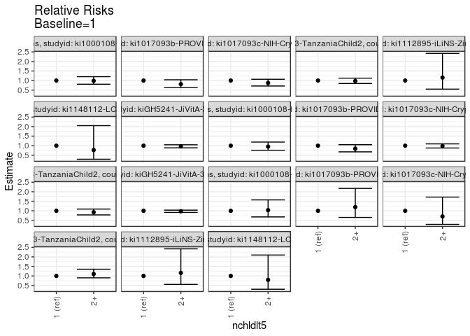

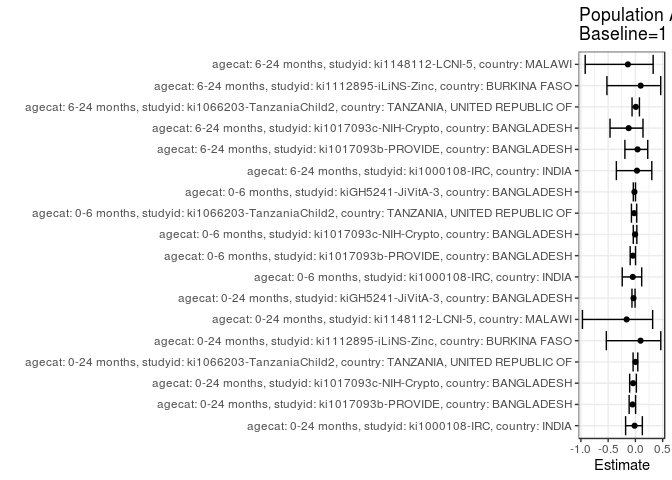

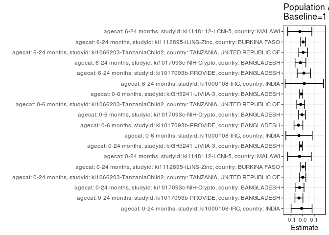

## Results Table

### Parameter: TSM

| agecat | studyid | country | intervention_level | baseline_level | estimate | ci_lower | ci_upper |
| --- | --- | --- | --- | --- | --- | --- | --- |
| 0-24 months | ki1000108-IRC | INDIA | 1 | NA | 0.5986497 | 0.4975136 | 0.6997858 |
| 0-24 months | ki1000108-IRC | INDIA | 2+ | NA | 0.5900268 | 0.5290655 | 0.6509880 |
| 0-24 months | ki1017093b-PROVIDE | BANGLADESH | 1 | NA | 0.6146877 | 0.5485871 | 0.6807883 |
| 0-24 months | ki1017093b-PROVIDE | BANGLADESH | 2+ | NA | 0.4989009 | 0.3880272 | 0.6097746 |
| 0-24 months | ki1017093c-NIH-Crypto | BANGLADESH | 1 | NA | 0.6501973 | 0.5841632 | 0.7162314 |
| 0-24 months | ki1017093c-NIH-Crypto | BANGLADESH | 2+ | NA | 0.5674301 | 0.4695907 | 0.6652696 |
| 0-24 months | ki1066203-TanzaniaChild2 | TANZANIA, UNITED REPUBLIC OF | 1 | NA | 0.6250531 | 0.5788416 | 0.6712646 |
| 0-24 months | ki1066203-TanzaniaChild2 | TANZANIA, UNITED REPUBLIC OF | 2+ | NA | 0.6101114 | 0.5353311 | 0.6848917 |
| 0-24 months | ki1112895-iLiNS-Zinc | BURKINA FASO | 1 | NA | 0.0391269 | 0.0141334 | 0.0641203 |
| 0-24 months | ki1112895-iLiNS-Zinc | BURKINA FASO | 2+ | NA | 0.0452290 | 0.0280669 | 0.0623912 |
| 0-24 months | ki1148112-LCNI-5 | MALAWI | 1 | NA | 0.1935484 | 0.0643859 | 0.3227109 |
| 0-24 months | ki1148112-LCNI-5 | MALAWI | 2+ | NA | 0.1489362 | 0.0421700 | 0.2557024 |
| 0-24 months | kiGH5241-JiVitA-3 | BANGLADESH | 1 | NA | 0.4371635 | 0.4205834 | 0.4537435 |
| 0-24 months | kiGH5241-JiVitA-3 | BANGLADESH | 2+ | NA | 0.4211162 | 0.3897748 | 0.4524577 |
| 0-6 months | ki1000108-IRC | INDIA | 1 | NA | 0.6683584 | 0.5403192 | 0.7963976 |
| 0-6 months | ki1000108-IRC | INDIA | 2+ | NA | 0.6349954 | 0.5630832 | 0.7069076 |
| 0-6 months | ki1017093b-PROVIDE | BANGLADESH | 1 | NA | 0.8239718 | 0.7620032 | 0.8859404 |
| 0-6 months | ki1017093b-PROVIDE | BANGLADESH | 2+ | NA | 0.6941117 | 0.5502287 | 0.8379947 |
| 0-6 months | ki1017093c-NIH-Crypto | BANGLADESH | 1 | NA | 0.8992806 | 0.8486502 | 0.9499109 |
| 0-6 months | ki1017093c-NIH-Crypto | BANGLADESH | 2+ | NA | 0.8813559 | 0.7977878 | 0.9649240 |
| 0-6 months | ki1066203-TanzaniaChild2 | TANZANIA, UNITED REPUBLIC OF | 1 | NA | 0.7184675 | 0.6601480 | 0.7767869 |
| 0-6 months | ki1066203-TanzaniaChild2 | TANZANIA, UNITED REPUBLIC OF | 2+ | NA | 0.6646198 | 0.5695607 | 0.7596790 |
| 0-6 months | kiGH5241-JiVitA-3 | BANGLADESH | 1 | NA | 0.6875231 | 0.6685762 | 0.7064699 |
| 0-6 months | kiGH5241-JiVitA-3 | BANGLADESH | 2+ | NA | 0.6693607 | 0.6330560 | 0.7056655 |
| 6-24 months | ki1000108-IRC | INDIA | 1 | NA | 0.5014793 | 0.3146157 | 0.6883429 |
| 6-24 months | ki1000108-IRC | INDIA | 2+ | NA | 0.5182226 | 0.4203806 | 0.6160645 |
| 6-24 months | ki1017093b-PROVIDE | BANGLADESH | 1 | NA | 0.2656250 | 0.1665603 | 0.3646897 |
| 6-24 months | ki1017093b-PROVIDE | BANGLADESH | 2+ | NA | 0.3165549 | 0.1693971 | 0.4637126 |
| 6-24 months | ki1017093c-NIH-Crypto | BANGLADESH | 1 | NA | 0.1690141 | 0.0805585 | 0.2574696 |
| 6-24 months | ki1017093c-NIH-Crypto | BANGLADESH | 2+ | NA | 0.1190476 | 0.0331409 | 0.2049543 |
| 6-24 months | ki1066203-TanzaniaChild2 | TANZANIA, UNITED REPUBLIC OF | 1 | NA | 0.5519235 | 0.4868892 | 0.6169579 |
| 6-24 months | ki1066203-TanzaniaChild2 | TANZANIA, UNITED REPUBLIC OF | 2+ | NA | 0.6088720 | 0.5082508 | 0.7094931 |
| 6-24 months | ki1112895-iLiNS-Zinc | BURKINA FASO | 1 | NA | 0.0390328 | 0.0142859 | 0.0637798 |
| 6-24 months | ki1112895-iLiNS-Zinc | BURKINA FASO | 2+ | NA | 0.0452234 | 0.0280732 | 0.0623735 |
| 6-24 months | ki1148112-LCNI-5 | MALAWI | 1 | NA | 0.2000000 | 0.0680734 | 0.3319266 |
| 6-24 months | ki1148112-LCNI-5 | MALAWI | 2+ | NA | 0.1590909 | 0.0462498 | 0.2719320 |

### Parameter: E(Y)

| agecat | studyid | country | intervention_level | baseline_level | estimate | ci_lower | ci_upper |
| --- | --- | --- | --- | --- | --- | --- | --- |
| 0-24 months | ki1000108-IRC | INDIA | NA | NA | 0.5898734 | 0.5376978 | 0.6420491 |
| 0-24 months | ki1017093b-PROVIDE | BANGLADESH | NA | NA | 0.5830619 | 0.5262762 | 0.6398476 |
| 0-24 months | ki1017093c-NIH-Crypto | BANGLADESH | NA | NA | 0.6237942 | 0.5698223 | 0.6777662 |
| 0-24 months | ki1066203-TanzaniaChild2 | TANZANIA, UNITED REPUBLIC OF | NA | NA | 0.6258790 | 0.5881498 | 0.6636083 |
| 0-24 months | ki1112895-iLiNS-Zinc | BURKINA FASO | NA | NA | 0.0432020 | 0.0290622 | 0.0573419 |
| 0-24 months | ki1148112-LCNI-5 | MALAWI | NA | NA | 0.1666667 | 0.0842830 | 0.2490503 |
| 0-24 months | kiGH5241-JiVitA-3 | BANGLADESH | NA | NA | 0.4225482 | 0.4114219 | 0.4336746 |
| 0-6 months | ki1000108-IRC | INDIA | NA | NA | 0.6375000 | 0.5751450 | 0.6998550 |
| 0-6 months | ki1017093b-PROVIDE | BANGLADESH | NA | NA | 0.7880435 | 0.7295878 | 0.8464992 |
| 0-6 months | ki1017093c-NIH-Crypto | BANGLADESH | NA | NA | 0.8939394 | 0.8505280 | 0.9373508 |
| 0-6 months | ki1066203-TanzaniaChild2 | TANZANIA, UNITED REPUBLIC OF | NA | NA | 0.7020649 | 0.6526590 | 0.7514708 |
| 0-6 months | kiGH5241-JiVitA-3 | BANGLADESH | NA | NA | 0.6753274 | 0.6619885 | 0.6886664 |
| 6-24 months | ki1000108-IRC | INDIA | NA | NA | 0.5161290 | 0.4322562 | 0.6000019 |
| 6-24 months | ki1017093b-PROVIDE | BANGLADESH | NA | NA | 0.2764228 | 0.1950773 | 0.3577682 |
| 6-24 months | ki1017093c-NIH-Crypto | BANGLADESH | NA | NA | 0.1504425 | 0.0860251 | 0.2148599 |
| 6-24 months | ki1066203-TanzaniaChild2 | TANZANIA, UNITED REPUBLIC OF | NA | NA | 0.5564516 | 0.5041613 | 0.6087419 |
| 6-24 months | ki1112895-iLiNS-Zinc | BURKINA FASO | NA | NA | 0.0432020 | 0.0290622 | 0.0573419 |
| 6-24 months | ki1148112-LCNI-5 | MALAWI | NA | NA | 0.1756757 | 0.0897916 | 0.2615597 |

### Parameter: RR

| agecat | studyid | country | intervention_level | baseline_level | estimate | ci_lower | ci_upper |
| --- | --- | --- | --- | --- | --- | --- | --- |
| 0-24 months | ki1000108-IRC | INDIA | 1 | 1 | 1.0000000 | 1.0000000 | 1.000000 |
| 0-24 months | ki1000108-IRC | INDIA | 2+ | 1 | 0.9855960 | 0.8082716 | 1.201823 |
| 0-24 months | ki1017093b-PROVIDE | BANGLADESH | 1 | 1 | 1.0000000 | 1.0000000 | 1.000000 |
| 0-24 months | ki1017093b-PROVIDE | BANGLADESH | 2+ | 1 | 0.8116331 | 0.6336885 | 1.039546 |
| 0-24 months | ki1017093c-NIH-Crypto | BANGLADESH | 1 | 1 | 1.0000000 | 1.0000000 | 1.000000 |
| 0-24 months | ki1017093c-NIH-Crypto | BANGLADESH | 2+ | 1 | 0.8727045 | 0.7136879 | 1.067152 |
| 0-24 months | ki1066203-TanzaniaChild2 | TANZANIA, UNITED REPUBLIC OF | 1 | 1 | 1.0000000 | 1.0000000 | 1.000000 |
| 0-24 months | ki1066203-TanzaniaChild2 | TANZANIA, UNITED REPUBLIC OF | 2+ | 1 | 0.9760954 | 0.8459050 | 1.126323 |
| 0-24 months | ki1112895-iLiNS-Zinc | BURKINA FASO | 1 | 1 | 1.0000000 | 1.0000000 | 1.000000 |
| 0-24 months | ki1112895-iLiNS-Zinc | BURKINA FASO | 2+ | 1 | 1.1559576 | 0.5509518 | 2.425327 |
| 0-24 months | ki1148112-LCNI-5 | MALAWI | 1 | 1 | 1.0000000 | 1.0000000 | 1.000000 |
| 0-24 months | ki1148112-LCNI-5 | MALAWI | 2+ | 1 | 0.7695035 | 0.2889550 | 2.049231 |
| 0-24 months | kiGH5241-JiVitA-3 | BANGLADESH | 1 | 1 | 1.0000000 | 1.0000000 | 1.000000 |
| 0-24 months | kiGH5241-JiVitA-3 | BANGLADESH | 2+ | 1 | 0.9632924 | 0.8863510 | 1.046913 |
| 0-6 months | ki1000108-IRC | INDIA | 1 | 1 | 1.0000000 | 1.0000000 | 1.000000 |
| 0-6 months | ki1000108-IRC | INDIA | 2+ | 1 | 0.9500821 | 0.7597883 | 1.188036 |
| 0-6 months | ki1017093b-PROVIDE | BANGLADESH | 1 | 1 | 1.0000000 | 1.0000000 | 1.000000 |
| 0-6 months | ki1017093b-PROVIDE | BANGLADESH | 2+ | 1 | 0.8423974 | 0.6758528 | 1.049982 |
| 0-6 months | ki1017093c-NIH-Crypto | BANGLADESH | 1 | 1 | 1.0000000 | 1.0000000 | 1.000000 |
| 0-6 months | ki1017093c-NIH-Crypto | BANGLADESH | 2+ | 1 | 0.9800678 | 0.8777383 | 1.094327 |
| 0-6 months | ki1066203-TanzaniaChild2 | TANZANIA, UNITED REPUBLIC OF | 1 | 1 | 1.0000000 | 1.0000000 | 1.000000 |
| 0-6 months | ki1066203-TanzaniaChild2 | TANZANIA, UNITED REPUBLIC OF | 2+ | 1 | 0.9250521 | 0.7847507 | 1.090437 |
| 0-6 months | kiGH5241-JiVitA-3 | BANGLADESH | 1 | 1 | 1.0000000 | 1.0000000 | 1.000000 |
| 0-6 months | kiGH5241-JiVitA-3 | BANGLADESH | 2+ | 1 | 0.9735829 | 0.9163589 | 1.034380 |
| 6-24 months | ki1000108-IRC | INDIA | 1 | 1 | 1.0000000 | 1.0000000 | 1.000000 |
| 6-24 months | ki1000108-IRC | INDIA | 2+ | 1 | 1.0333878 | 0.6793771 | 1.571867 |
| 6-24 months | ki1017093b-PROVIDE | BANGLADESH | 1 | 1 | 1.0000000 | 1.0000000 | 1.000000 |
| 6-24 months | ki1017093b-PROVIDE | BANGLADESH | 2+ | 1 | 1.1917360 | 0.6536126 | 2.172900 |
| 6-24 months | ki1017093c-NIH-Crypto | BANGLADESH | 1 | 1 | 1.0000000 | 1.0000000 | 1.000000 |
| 6-24 months | ki1017093c-NIH-Crypto | BANGLADESH | 2+ | 1 | 0.7043651 | 0.2888063 | 1.717865 |
| 6-24 months | ki1066203-TanzaniaChild2 | TANZANIA, UNITED REPUBLIC OF | 1 | 1 | 1.0000000 | 1.0000000 | 1.000000 |
| 6-24 months | ki1066203-TanzaniaChild2 | TANZANIA, UNITED REPUBLIC OF | 2+ | 1 | 1.1031818 | 0.9008149 | 1.351010 |
| 6-24 months | ki1112895-iLiNS-Zinc | BURKINA FASO | 1 | 1 | 1.0000000 | 1.0000000 | 1.000000 |
| 6-24 months | ki1112895-iLiNS-Zinc | BURKINA FASO | 2+ | 1 | 1.1585980 | 0.5546389 | 2.420222 |
| 6-24 months | ki1148112-LCNI-5 | MALAWI | 1 | 1 | 1.0000000 | 1.0000000 | 1.000000 |
| 6-24 months | ki1148112-LCNI-5 | MALAWI | 2+ | 1 | 0.7954545 | 0.3019242 | 2.095718 |

### Parameter: PAR

| agecat | studyid | country | intervention_level | baseline_level | estimate | ci_lower | ci_upper |
| --- | --- | --- | --- | --- | --- | --- | --- |
| 0-24 months | ki1000108-IRC | INDIA | 1 | NA | -0.0087763 | -0.0988922 | 0.0813396 |
| 0-24 months | ki1017093b-PROVIDE | BANGLADESH | 1 | NA | -0.0316258 | -0.0659018 | 0.0026501 |
| 0-24 months | ki1017093c-NIH-Crypto | BANGLADESH | 1 | NA | -0.0264031 | -0.0646564 | 0.0118501 |
| 0-24 months | ki1066203-TanzaniaChild2 | TANZANIA, UNITED REPUBLIC OF | 1 | NA | 0.0008260 | -0.0260320 | 0.0276839 |
| 0-24 months | ki1112895-iLiNS-Zinc | BURKINA FASO | 1 | NA | 0.0040752 | -0.0164745 | 0.0246249 |
| 0-24 months | ki1148112-LCNI-5 | MALAWI | 1 | NA | -0.0268817 | -0.1281436 | 0.0743802 |
| 0-24 months | kiGH5241-JiVitA-3 | BANGLADESH | 1 | NA | -0.0146152 | -0.0265606 | -0.0026699 |
| 0-6 months | ki1000108-IRC | INDIA | 1 | NA | -0.0308584 | -0.1440021 | 0.0822852 |
| 0-6 months | ki1017093b-PROVIDE | BANGLADESH | 1 | NA | -0.0359283 | -0.0737910 | 0.0019344 |
| 0-6 months | ki1017093c-NIH-Crypto | BANGLADESH | 1 | NA | -0.0053412 | -0.0344810 | 0.0237986 |
| 0-6 months | ki1066203-TanzaniaChild2 | TANZANIA, UNITED REPUBLIC OF | 1 | NA | -0.0164026 | -0.0502526 | 0.0174475 |
| 0-6 months | kiGH5241-JiVitA-3 | BANGLADESH | 1 | NA | -0.0121957 | -0.0257170 | 0.0013257 |
| 6-24 months | ki1000108-IRC | INDIA | 1 | NA | 0.0146497 | -0.1499763 | 0.1792758 |
| 6-24 months | ki1017093b-PROVIDE | BANGLADESH | 1 | NA | 0.0107978 | -0.0466005 | 0.0681960 |
| 6-24 months | ki1017093c-NIH-Crypto | BANGLADESH | 1 | NA | -0.0185716 | -0.0649036 | 0.0277604 |
| 6-24 months | ki1066203-TanzaniaChild2 | TANZANIA, UNITED REPUBLIC OF | 1 | NA | 0.0045281 | -0.0330250 | 0.0420812 |
| 6-24 months | ki1112895-iLiNS-Zinc | BURKINA FASO | 1 | NA | 0.0041692 | -0.0161570 | 0.0244954 |
| 6-24 months | ki1148112-LCNI-5 | MALAWI | 1 | NA | -0.0243243 | -0.1278155 | 0.0791669 |

### Parameter: PAF

| agecat | studyid | country | intervention_level | baseline_level | estimate | ci_lower | ci_upper |
| --- | --- | --- | --- | --- | --- | --- | --- |
| 0-24 months | ki1000108-IRC | INDIA | 1 | NA | -0.0148783 | -0.1798542 | 0.1270295 |
| 0-24 months | ki1017093b-PROVIDE | BANGLADESH | 1 | NA | -0.0542410 | -0.1149906 | 0.0031988 |
| 0-24 months | ki1017093c-NIH-Crypto | BANGLADESH | 1 | NA | -0.0423266 | -0.1056207 | 0.0173440 |
| 0-24 months | ki1066203-TanzaniaChild2 | TANZANIA, UNITED REPUBLIC OF | 1 | NA | 0.0013197 | -0.0425276 | 0.0433229 |
| 0-24 months | ki1112895-iLiNS-Zinc | BURKINA FASO | 1 | NA | 0.0943279 | -0.5332308 | 0.4650238 |
| 0-24 months | ki1148112-LCNI-5 | MALAWI | 1 | NA | -0.1612903 | -0.9712387 | 0.3158641 |
| 0-24 months | kiGH5241-JiVitA-3 | BANGLADESH | 1 | NA | -0.0345883 | -0.0632333 | -0.0067150 |
| 0-6 months | ki1000108-IRC | INDIA | 1 | NA | -0.0484054 | -0.2419851 | 0.1150024 |
| 0-6 months | ki1017093b-PROVIDE | BANGLADESH | 1 | NA | -0.0455918 | -0.0956841 | 0.0022104 |
| 0-6 months | ki1017093c-NIH-Crypto | BANGLADESH | 1 | NA | -0.0059749 | -0.0391273 | 0.0261198 |
| 0-6 months | ki1066203-TanzaniaChild2 | TANZANIA, UNITED REPUBLIC OF | 1 | NA | -0.0233633 | -0.0728570 | 0.0238471 |
| 0-6 months | kiGH5241-JiVitA-3 | BANGLADESH | 1 | NA | -0.0180589 | -0.0382841 | 0.0017723 |
| 6-24 months | ki1000108-IRC | INDIA | 1 | NA | 0.0283838 | -0.3493932 | 0.3003982 |
| 6-24 months | ki1017093b-PROVIDE | BANGLADESH | 1 | NA | 0.0390625 | -0.1929715 | 0.2259657 |
| 6-24 months | ki1017093c-NIH-Crypto | BANGLADESH | 1 | NA | -0.1234466 | -0.4658052 | 0.1389496 |
| 6-24 months | ki1066203-TanzaniaChild2 | TANZANIA, UNITED REPUBLIC OF | 1 | NA | 0.0081374 | -0.0617205 | 0.0733989 |
| 6-24 months | ki1112895-iLiNS-Zinc | BURKINA FASO | 1 | NA | 0.0965047 | -0.5225598 | 0.4638610 |
| 6-24 months | ki1148112-LCNI-5 | MALAWI | 1 | NA | -0.1384615 | -0.9209109 | 0.3252708 |